# Inside Item Memory

> This notebook focuses on item memory inside the rooms.

# 1 Overview of the data

The rooms were separated into *Familiar* and *Novel* groups. Participants explored the *Familiar* group at the beginning of the experiment. In the encoding task, they visisted both *Familiar* and *Novel* groups. Their item memory (i.e., in which room they saw the item) was tested in the memory test the next day of the encoding task. **Novelty benefits** on the item memory are examined by comparing the memory performance between the *Familiar* and *Novel* groups.

Participants were also asked to rate how curious they felt about the room. The higher the rating is means they felt more curious about the room. Item memory as a function of curiosity rating was also examined for **curiosity benefits**.

Questionnaires on personal traits regarding curiosity were also administered to participants before the encoding task (i.e., PC and EC). Scores on these questionnaires might be able to predict the item memory or its relationship with curiosity rating.

In the encoding task, there were 6 objects in each room, and the participant saw the object after openning each of the six box. It is possbile that the item memory for the object to some extent depends on the order in which the object was seen. For example, it may be easier to remember where the first and last objects were seen as compared to those in the middle.

# 2 Visual inspection of the data

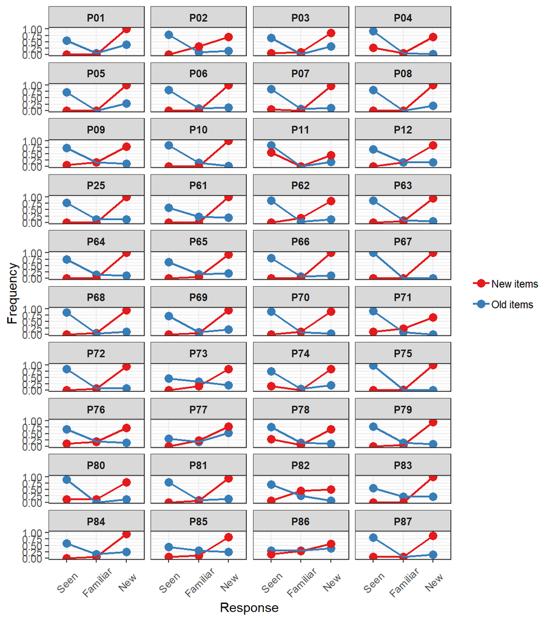

Figure 1. Response frequency for new and old items respectively for each individual participant.

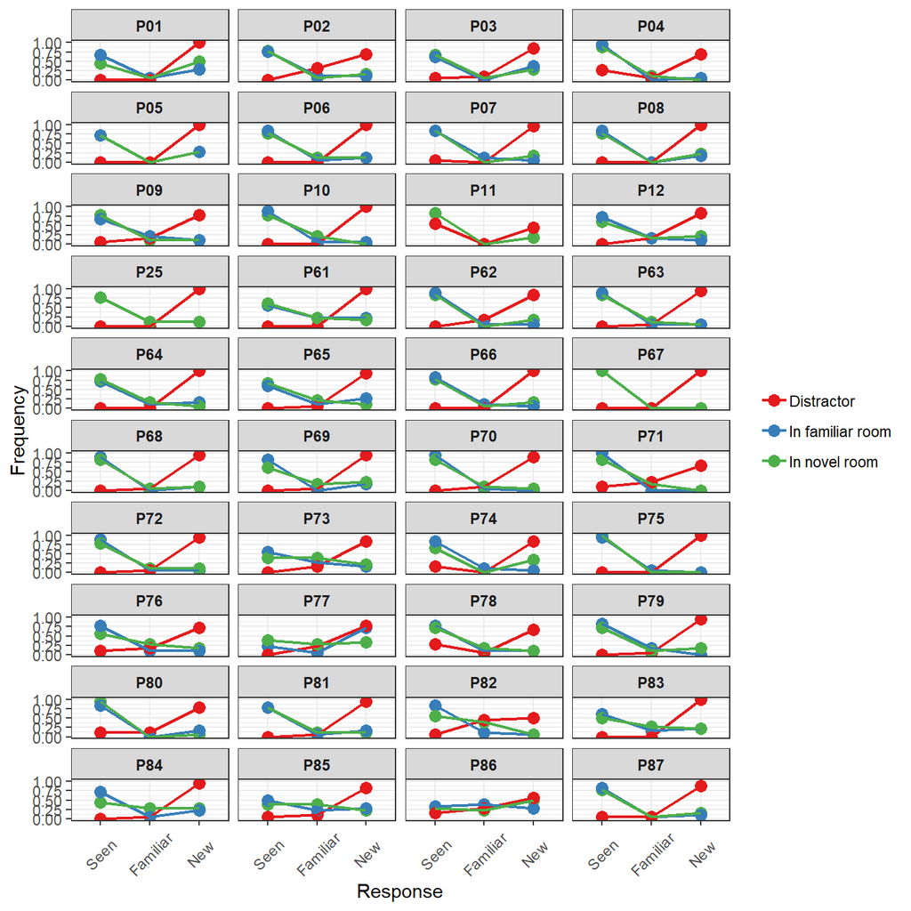

Figure 2. Response frequency for new and old items respectively for each Familiar/Novel group and each individual participant.

```r
Encoding.Recall.Freq.Grp$Type <- "Good"
Encoding.Recall.Freq.Grp[SubjectNo %in% bad.ps.less.strict]$Type <- "Bad"

Encoding.Recall.Freq.Rsp$Type <- "Good"
Encoding.Recall.Freq.Rsp[SubjectNo %in% bad.ps.less.strict]$Type <- "Bad"
```

# 3 Novelty Benefits

## 3.1 Compare mean accuracy between *novel* and *familiar* rooms

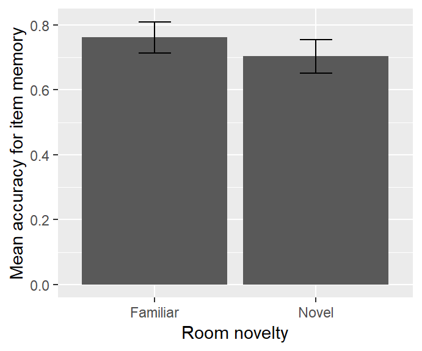

Figure 3. Mean hit rate for recollect response respectively for Familiar and Novel rooms.

```
##
##  Paired t-test
##
## data:  MeanSeenHit by Group
## t = 3.6022, df = 39, p-value = 0.0008811
## alternative hypothesis: true difference in means is not equal to 0
## 95 percent confidence interval:
##  0.02618705 0.09325740
## sample estimates:
## mean of the differences
##              0.05972222
```

## 3.2 Item memory as a function of item order

### 3.2.1 Visualise the data

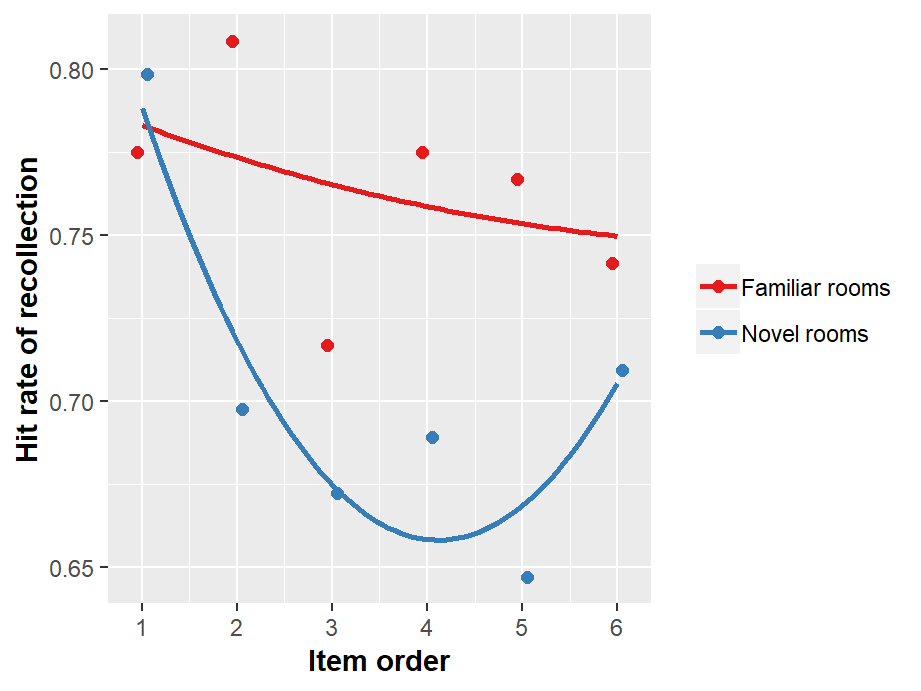

Figure 4. Mean hit rate for seen response for items at each order (i.e., 1st, 2nd, 3rd, etc), respectively for familiar and novel rooms.

### 3.2.2 Testing novelty effects by fitting mixed models

Build models with item memory accuracy as $y$ and iexamine effects of item order and novelty by comparing the models.

- `baseline.item` is the model with only an intercept.
- `order.model.linear.1` is the model with $\small ItemOrder$ included, showing the effects of item order.
- `order.model.linear.2` is the model allowing the slope (i.e., relationship between item memory and item order) varying across participants.
- `order.model.quad.1` and `order.model.quad.2` repectively included $\small ItemOrder^2$ and related random effects.
- `novelty.model.1` is the model with $\small Group$ (i.e., *familiar* and *novel* rooms) included, examining the effects of novelty of the rooms on the intercept (i.e., mean item memory accuracy at the 1st order or overall if no difference in slope).
- `novelty.model.2` is the model with interaction between $\small Group$ and $\small ItemOrder$ included, examining the effects of novelty on how item memory accuracy changes as a function of item order.
- `novelty.model.3` included interaction between $\small Group$ and $\small ItemOrder^2$ for inestigating whether the pattern changes between *familiar* and *novel* groups.

```
##                      Model df      AIC      BIC    logLik   Test  L.Ratio
## order.model.linear.1     1  5 1636.806 1663.127 -813.4032
## order.model.linear.2     2  9 1642.804 1690.180 -812.4021 1 vs 2 2.002132
## order.model.quad.1       3 10 1642.216 1694.856 -811.1078 2 vs 3 2.588621
## novelty.model.1          4 11 1636.606 1694.511 -807.3032 3 vs 4 7.609202
## novelty.model.2          5 12 1638.043 1701.212 -807.0217 4 vs 5 0.563118
## novelty.model.3          6 13 1637.941 1706.374 -805.9707 5 vs 6 2.101817
##                      p-value
## order.model.linear.1
## order.model.linear.2  0.7354
## order.model.quad.1    0.1076
## novelty.model.1       0.0058
## novelty.model.2       0.4530
## novelty.model.3       0.1471
```

#### 3.2.2.1 Parameter estimation for the complete model

```
## Linear mixed-effects model fit by maximum likelihood
##  Data: Encoding.Recall.Old[!SubjectNo %in% bad.ps.less.strict]
##        AIC      BIC    logLik
##   1637.941 1706.374 -805.9707
##
## Random effects:
##  Formula: ~1 + ItemOrder | SubjectNo
##  Structure: General positive-definite, Log-Cholesky parametrization
##             StdDev     Corr
## (Intercept) 0.12014748 (Intr)
## ItemOrder   0.01762191 0.141
##
##  Formula: ~1 + ItemOrder | Group %in% SubjectNo
##  Structure: General positive-definite, Log-Cholesky parametrization
##             StdDev       Corr
## (Intercept) 4.379161e-04 (Intr)
## ItemOrder   3.982603e-06 0
## Residual    4.149937e-01
##
## Fixed effects: SeenHit ~ ItemOrder + I(ItemOrder^2) + Group + ItemOrder:Group +      I(ItemOrder^2):Group
##                                Value  Std.Error   DF   t-value p-value
## (Intercept)                0.7943502 0.07062123 1344 11.248037  0.0000
## ItemOrder                 -0.0120520 0.04465287 1344 -0.269903  0.7873
## I(ItemOrder^2)             0.0007768 0.00624659 1344  0.124359  0.9011
## GroupNovel                 0.0920791 0.09634420   39  0.955731  0.3451
## ItemOrder:GroupNovel      -0.0990559 0.06310647 1344 -1.569663  0.1167
## I(ItemOrder^2):GroupNovel  0.0127890 0.00884008 1344  1.446710  0.1482
##  Correlation:
##                           (Intr) ItmOrd I(ItO^2) GrpNvl ItO:GN
## ItemOrder                 -0.893
## I(ItemOrder^2)             0.822 -0.977
## GroupNovel                -0.680  0.656 -0.603
## ItemOrder:GroupNovel       0.633 -0.705  0.691   -0.931
## I(ItemOrder^2):GroupNovel -0.581  0.690 -0.707    0.854 -0.979
##
## Standardized Within-Group Residuals:
##        Min         Q1        Med         Q3        Max
## -2.2799822 -0.8739848  0.4204700  0.6253877  1.7142385
##
## Number of Observations: 1428
## Number of Groups:
##            SubjectNo Group %in% SubjectNo
##                   40                   80
```

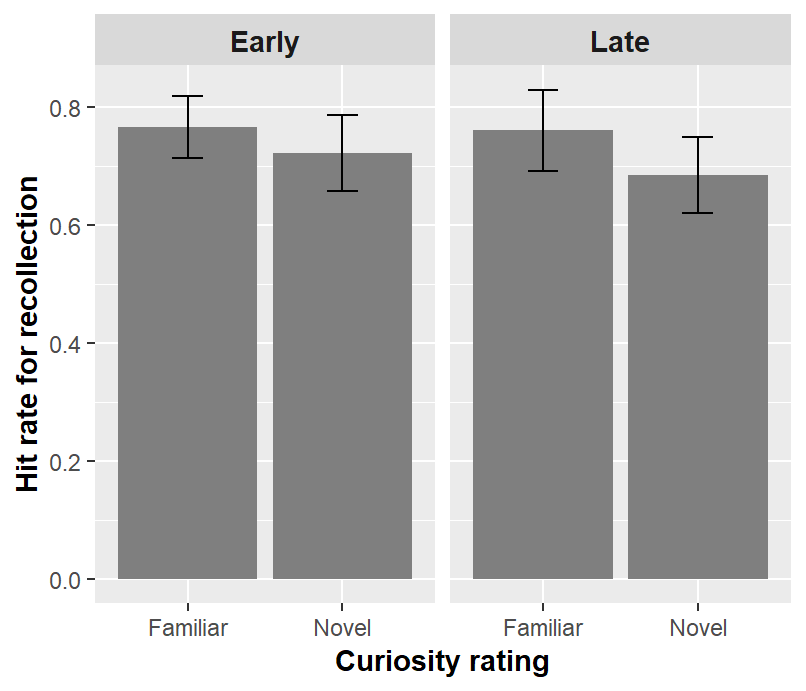

#### 3.2.3.1 Stats on it

```
## Linear mixed-effects model fit by maximum likelihood
##  Data: Encoding.Recall.Old.Collapsed.Grp[!SubjectNo %in% bad.ps.less.strict]
##         AIC       BIC   logLik
##   -116.1253 -91.52391 66.06265
##
## Random effects:
##  Formula: ~1 | SubjectNo
##         (Intercept)
## StdDev:    0.145599
##
##  Formula: ~1 | Group %in% SubjectNo
##         (Intercept)
## StdDev: 3.76174e-06
##
##  Formula: ~1 | ItemOrderType %in% Group %in% SubjectNo
##         (Intercept)   Residual
## StdDev:   0.1273898 0.00199546
##
## Fixed effects: SeenHit ~ Group * ItemOrderType
##                                   Value  Std.Error DF   t-value p-value
## (Intercept)                   0.7666667 0.03098023 78 24.746968  0.0000
## GroupNovel                   -0.0444444 0.02885164 39 -1.540448  0.1315
## ItemOrderTypeLate            -0.0057540 0.02885164 78 -0.199433  0.8424
## GroupNovel:ItemOrderTypeLate -0.0313988 0.04080238 78 -0.769534  0.4439
##  Correlation:
##                              (Intr) GrpNvl ItmOTL
## GroupNovel                   -0.466
## ItemOrderTypeLate            -0.466  0.500
## GroupNovel:ItemOrderTypeLate  0.329 -0.707 -0.707
##
## Standardized Within-Group Residuals:
##          Min           Q1          Med           Q3          Max
## -0.035703566 -0.008912539  0.001880506  0.008293287  0.036005636
##
## Number of Observations: 160
## Number of Groups:
##                               SubjectNo
##                                      40
##                    Group %in% SubjectNo
##                                      80
## ItemOrderType %in% Group %in% SubjectNo
##                                     160
```

# 4 Curiosity Benefits

We hypothesed that the higher the curiosity rating was, the better the item memory should be.

## 4.1 Mean accuracy of item memory as a function of curiosity rating

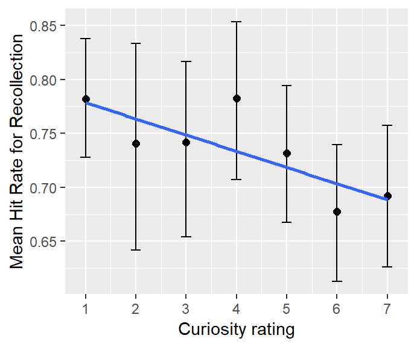

Figure 5. Mean hit rate as a function of curiosity rating.

### 4.1.1 Testing the relationship between mean accuracy of item memory and curiosity rating

Build models with item memory accuracy as $y$ and examine effects of curiosity rating by including it into the model and then comparing the model fits.

- `baseline.rating` is the model with only an intercept, showing no change in item memory as a function of curiosity rating.
- `rating.intercept` is the model with $\small CuriosityRating$ included, showing the effects of curiosity rating.
- `rating.slope` is the model allowing the slope (i.e., relationship between item memory and curiosity rating) varying across participants.

```
##                  Model df       AIC        BIC   logLik   Test  L.Ratio
## baseline.rating      1  3 -110.2669  -99.83755 58.13347
## rating.intercept     2  4 -117.1674 -103.26153 62.58369 1 vs 2 8.900448
## rating.slope         3  6 -113.1673  -92.30856 62.58367 2 vs 3 0.000040
##                  p-value
## baseline.rating
## rating.intercept  0.0029
## rating.slope      1.0000
```

#### 4.1.1.1 Parameter estimates in the complete model

```r
summary(rating.slope)
```

```
## Linear mixed-effects model fit by maximum likelihood
##  Data: InsideObjectsMemory[!SubjectNo %in% bad.ps.less.strict]
##         AIC       BIC   logLik
##   -113.1673 -92.30856 62.58367
##
## Random effects:
##  Formula: ~1 + CuriosityRating | SubjectNo
##  Structure: General positive-definite, Log-Cholesky parametrization
##                 StdDev       Corr
## (Intercept)     1.449088e-01 (Intr)
## CuriosityRating 4.419835e-05 -0.001
## Residual        1.606072e-01
##
## Fixed effects: SeenHit ~ CuriosityRating
##                      Value  Std.Error  DF   t-value p-value
## (Intercept)      0.7982541 0.03328710 198 23.980882   0.000
## CuriosityRating -0.0160630 0.00534429 198 -3.005644   0.003
##  Correlation:
##                 (Intr)
## CuriosityRating -0.651
##
## Standardized Within-Group Residuals:
##        Min         Q1        Med         Q3        Max
## -2.7845785 -0.5822157  0.1348160  0.6353465  2.3518779
##
## Number of Observations: 239
## Number of Groups: 40
```

#### 4.1.1.2 Plot the model

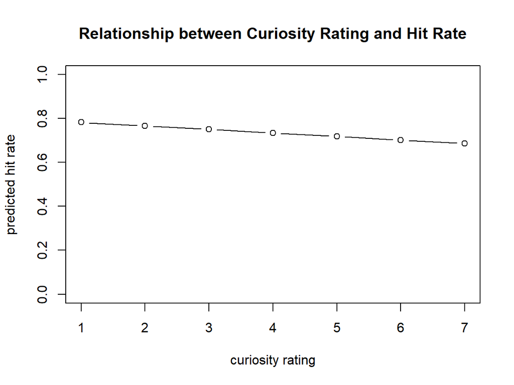

After taking into account individual difference, the estimated slope (relationship between curiosity rating and item memory) is weakly negative

## 4.2 Does the relationship with curiosity rating depend on item order?

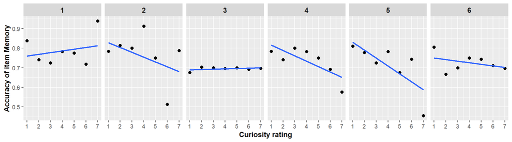

Figure 6. Mean accuracy across participants for item memory as a function of curiosity rating for each order at which the item was seen (I.e., 1st, 2nd, 3rd, etc.).

### 4.2.1 Testing the effect of item order

- `item.model.linear.1` is the model with $\small ItemOrder$ included (in addition to $\small CuriosityRating$), showing the effects of item order.
- `item.model.linear.2` is the model allowing the slope (i.e., relationship between item memory and item order) varying across participants.
- `item.model.linear.3` is the model with the interaction between $\small ItemOrders$ and $\small CuriosityRating$ included.
- `item.model.quad.1` and `item.model.quad.2` repectively included $\small ItemOrder^2$ and related random effects.
- `item.model.quad.3` included interaction between $\small ItemOrder^2$ and $\small CuriosityRating$ for inestigating whether the pattern changes as a function of *curiosity rating*.

```r
baseline.item <- lme(SeenHit ~ 1, random = ~ 1|SubjectNo, data = Encoding.Recall.Old[!SubjectNo %in% bad.ps.less.strict], method = "ML", control = list(msMaxIter = 500, opt = "optim", msVerbose=FALSE), na.action = na.exclude)

rating.intercept <- update(baseline.item, .~. + CuriosityRating)
rating.slope     <- update(rating.intercept, random = ~ 1 + CuriosityRating | SubjectNo)

item.model.linear.1     <- update(rating.slope, .~. + ItemOrder)
item.model.linear.2     <- update(item.model.linear.1, random = list(~1+CuriosityRating+ItemOrder|SubjectNo))
item.model.linear.3     <- update(item.model.linear.2, .~. + ItemOrder : CuriosityRating)

item.model.quad.1       <- update(item.model.linear.3, .~. + I(ItemOrder^2))
# item.model.quad.2       <- update(item.model.quad.1,   random = list(~1+CuriosityRating|SubjectNo, ~1+ItemOrder+I(ItemOrder^2)|SubjectNo)) - excluding this model because singularity issue (perhaps the model was getting too complex to be calculated)
item.model.quad.3       <- update(item.model.quad.1,   .~. + I(ItemOrder^2) : CuriosityRating)

anova(rating.intercept, rating.slope, item.model.linear.1, item.model.linear.2, item.model.linear.3, item.model.quad.1, item.model.quad.3)
```

```
##                     Model df      AIC      BIC    logLik   Test  L.Ratio
## rating.intercept        1  4 1629.927 1650.984 -810.9637
## rating.slope            2  6 1634.035 1665.619 -811.0174 1 vs 2 0.107550
## item.model.linear.1     3  7 1632.843 1669.692 -809.4218 2 vs 3 3.191349
## item.model.linear.2     4 10 1636.629 1689.269 -808.3144 3 vs 4 2.214682
## item.model.linear.3     5 11 1636.522 1694.426 -807.2608 4 vs 5 2.107316
## item.model.quad.1       6 12 1635.908 1699.077 -805.9542 5 vs 6 2.613173
## item.model.quad.3       7 13 1635.887 1704.319 -804.9435 6 vs 7 2.021468
##                     p-value
## rating.intercept
## rating.slope         0.9476
## item.model.linear.1  0.0740
## item.model.linear.2  0.5291
## item.model.linear.3  0.1466
## item.model.quad.1    0.1060
## item.model.quad.3    0.1551
```

#### 4.2.1.1 Parameter estimation for the complete model

```r
summary(item.model.quad.3)
```

```
## Linear mixed-effects model fit by maximum likelihood
##  Data: Encoding.Recall.Old[!SubjectNo %in% bad.ps.less.strict]
##        AIC      BIC    logLik
##   1635.887 1704.319 -804.9435
##
## Random effects:
##  Formula: ~1 + CuriosityRating + ItemOrder | SubjectNo
##  Structure: General positive-definite, Log-Cholesky parametrization
##                 StdDev       Corr
## (Intercept)     1.150945e-01 (Intr) CrstyR
## CuriosityRating 1.881641e-09 -0.097
## ItemOrder       1.585207e-02  0.332 -0.293
## Residual        4.148572e-01
##
## Fixed effects: SeenHit ~ CuriosityRating + ItemOrder + I(ItemOrder^2) + CuriosityRating:ItemOrder +      CuriosityRating:I(ItemOrder^2)
##                                     Value  Std.Error   DF   t-value
## (Intercept)                     0.7224601 0.10962279 1383  6.590419
## CuriosityRating                 0.0290883 0.02389089 1383  1.217547
## ItemOrder                       0.0453233 0.07072844 1383  0.640808
## I(ItemOrder^2)                 -0.0054187 0.00989522 1383 -0.547606
## CuriosityRating:ItemOrder      -0.0263389 0.01561705 1383 -1.686547
## CuriosityRating:I(ItemOrder^2)  0.0031013 0.00218577 1383  1.418851
##                                p-value
## (Intercept)                     0.0000
## CuriosityRating                 0.2236
## ItemOrder                       0.5218
## I(ItemOrder^2)                  0.5841
## CuriosityRating:ItemOrder       0.0919
## CuriosityRating:I(ItemOrder^2)  0.1562
##  Correlation:
##                                (Intr) CrstyR ItmOrd I(IO^2 CrR:IO
## CuriosityRating                -0.883
## ItemOrder                      -0.915  0.832
## I(ItemOrder^2)                  0.841 -0.763 -0.978
## CuriosityRating:ItemOrder       0.821 -0.930 -0.894  0.876
## CuriosityRating:I(ItemOrder^2) -0.752  0.852  0.875 -0.895 -0.979
##
## Standardized Within-Group Residuals:
##        Min         Q1        Med         Q3        Max
## -2.2698317 -0.8652996  0.4219159  0.6220917  1.7630793
##
## Number of Observations: 1428
## Number of Groups: 40
```

#### 4.2.1.2 Was the relationship significantly positive for the first object?

```r
baseline.item.first <- lme(SeenHit ~ 1, random = ~ 1|SubjectNo, data = Encoding.Recall.Old[!SubjectNo %in% bad.ps.less.strict & ItemOrder == 1], method = "ML", control = list(msMaxIter = 500, opt = "optim", msVerbose=FALSE), na.action = na.exclude)

rating.intercept.first <- update(baseline.item.first, .~. + CuriosityRating)
rating.slope.first     <- update(rating.intercept.first, random = ~ 1 + CuriosityRating|SubjectNo)

anova(baseline.item.first, rating.intercept.first, rating.slope.first)
```

```
##                        Model df      AIC      BIC    logLik   Test
## baseline.item.first        1  3 255.9254 266.3547 -124.9627
## rating.intercept.first     2  4 257.4967 271.4025 -124.7483 1 vs 2
## rating.slope.first         3  6 261.2585 282.1173 -124.6292 2 vs 3
##                          L.Ratio p-value
## baseline.item.first
## rating.intercept.first 0.4286906  0.5126
## rating.slope.first     0.2381791  0.8877
```

```r
summary(rating.intercept.first)
```

```
## Linear mixed-effects model fit by maximum likelihood
##  Data: Encoding.Recall.Old[!SubjectNo %in% bad.ps.less.strict & ItemOrder ==      1]
##        AIC      BIC    logLik
##   257.4967 271.4025 -124.7483
##
## Random effects:
##  Formula: ~1 | SubjectNo
##         (Intercept)  Residual
## StdDev:  0.09872177 0.3972206
##
## Fixed effects: SeenHit ~ CuriosityRating
##                     Value  Std.Error  DF   t-value p-value
## (Intercept)     0.7524773 0.06042926 198 12.452202  0.0000
## CuriosityRating 0.0084277 0.01291940 198  0.652327  0.5149
##  Correlation:
##                 (Intr)
## CuriosityRating -0.866
##
## Standardized Within-Group Residuals:
##        Min         Q1        Med         Q3        Max
## -2.0547051  0.3314644  0.4434836  0.5674368  0.8648859
##
## Number of Observations: 239
## Number of Groups: 40
```

### 4.2.2 Collapse the order and curiosity rating

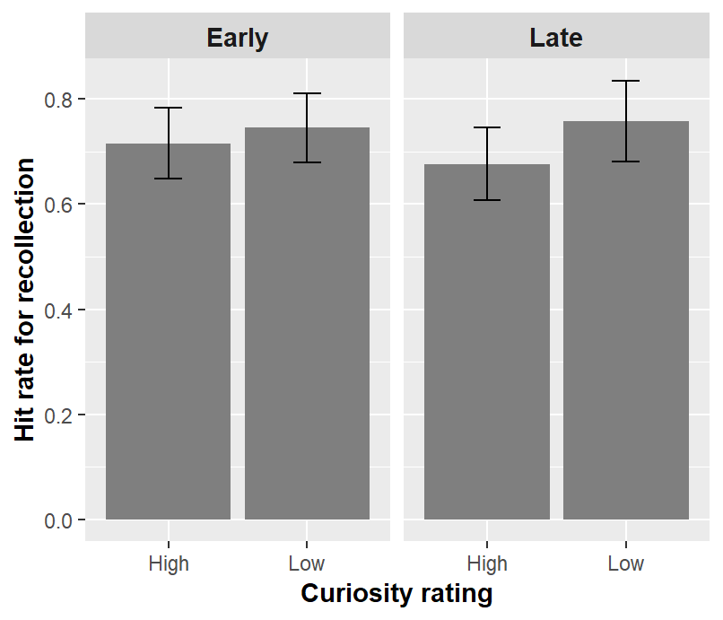

Figure 7. Mean hit rate as a function of item order (Early vs. Late) and curiosity (Low vs. High).

### 4.2.3 Try another way to calculate “High” and “Low” curiosity groups

> “High” - higher than mean; “Low” - lower than mean

#### 4.2.3.1 Compare “High” and “Low” groups

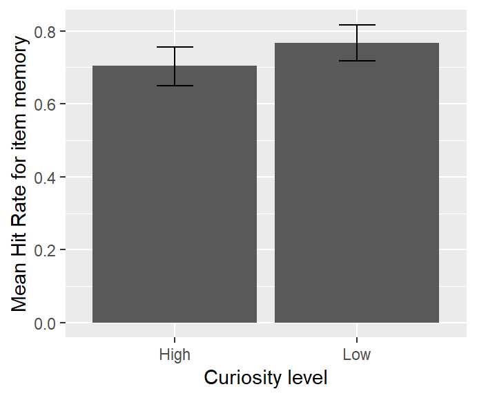

```
##
##  Paired t-test
##
## data:  SeenHit by RatingGroup
## t = -3.9823, df = 39, p-value = 0.0002887
## alternative hypothesis: true difference in means is not equal to 0
## 95 percent confidence interval:
##  -0.09475298 -0.03092104
## sample estimates:
## mean of the differences
##             -0.06283701
```

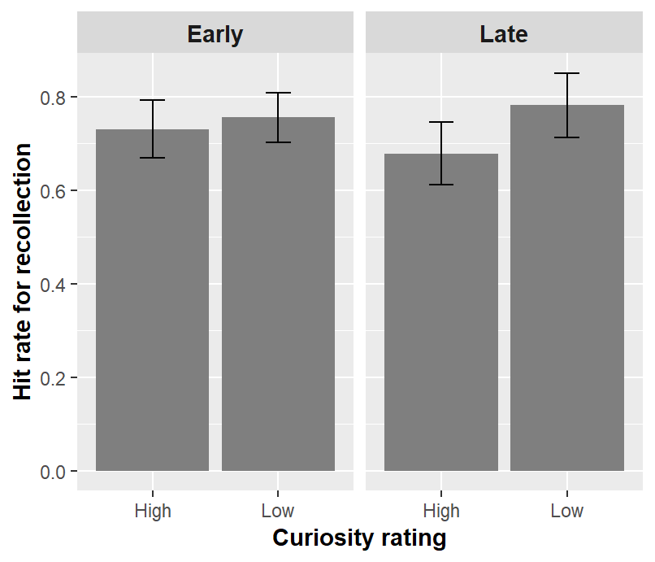

#### 4.2.3.2 Stats on it

```
## Linear mixed-effects model fit by maximum likelihood
##  Data: Encoding.Recall.Old.Collapsed.Alt[!SubjectNo %in% bad.ps.less.strict]
##         AIC       BIC   logLik
##   -106.3051 -81.70367 61.15253
##
## Random effects:
##  Formula: ~1 | SubjectNo
##         (Intercept)
## StdDev:   0.1413943
##
##  Formula: ~1 | RatingGroup %in% SubjectNo
##          (Intercept)
## StdDev: 0.0005570736
##
##  Formula: ~1 | ItemOrderType %in% RatingGroup %in% SubjectNo
##         (Intercept)    Residual
## StdDev:    0.133076 0.009997524
##
## Fixed effects: SeenHit ~ RatingGroup * ItemOrderType
##                                       Value  Std.Error DF   t-value
## (Intercept)                       0.7305556 0.03113322 78 23.465466
## RatingGroupLow                    0.0250000 0.03022096 39  0.827240
## ItemOrderTypeLate                -0.0521329 0.03022070 78 -1.725074
## RatingGroupLow:ItemOrderTypeLate  0.0777282 0.04273852 78  1.818691
##                                  p-value
## (Intercept)                       0.0000
## RatingGroupLow                    0.4131
## ItemOrderTypeLate                 0.0885
## RatingGroupLow:ItemOrderTypeLate  0.0728
##  Correlation:
##                                  (Intr) RtngGL ItmOTL
## RatingGroupLow                   -0.485
## ItemOrderTypeLate                -0.485  0.500
## RatingGroupLow:ItemOrderTypeLate  0.343 -0.707 -0.707
##
## Standardized Within-Group Residuals:
##          Min           Q1          Med           Q3          Max
## -0.170176000 -0.042098920  0.004848353  0.045732355  0.183283195
##
## Number of Observations: 160
## Number of Groups:
##                                     SubjectNo
##                                            40
##                    RatingGroup %in% SubjectNo
##                                            80
## ItemOrderType %in% RatingGroup %in% SubjectNo
##                                           160
```

# 5 Curiosity and novelty

## 5.1 Testing the effects of curiosity rating and novelty together

Build models with item memory accuracy as $y$ and examine effects of curiosity rating and novelty together by including them into the model separately and then comparing the model fits.

```
##                   Model df       AIC       BIC   logLik   Test  L.Ratio
## baseline.rating       1  4 -108.2639 -94.35800 58.13193
## rating.intercept      2  5 -115.1652 -97.78289 62.58260 1 vs 2 8.901354
## rating.slope          3  9 -107.1662 -75.87800 62.58308 2 vs 3 0.000962
## novelty.model         4 10 -105.8975 -71.13282 62.94873 3 vs 4 0.731288
## interaction.model     5 11 -103.9460 -65.70492 62.97301 4 vs 5 0.048565
##                   p-value
## baseline.rating
## rating.intercept   0.0028
## rating.slope       1.0000
## novelty.model      0.3925
## interaction.model  0.8256
```

### 5.1.1 Check the complete model

```
## Linear mixed-effects model fit by maximum likelihood
##  Data: InsideObjectsMemory[!SubjectNo %in% bad.ps.less.strict]
##        AIC       BIC   logLik
##   -103.946 -65.70492 62.97301
##
## Random effects:
##  Formula: ~1 + CuriosityRating | SubjectNo
##  Structure: General positive-definite, Log-Cholesky parametrization
##                 StdDev       Corr
## (Intercept)     1.447988e-01 (Intr)
## CuriosityRating 6.077373e-06 0
##
##  Formula: ~1 + CuriosityRating | Group %in% SubjectNo
##  Structure: General positive-definite, Log-Cholesky parametrization
##                 StdDev       Corr
## (Intercept)     7.866023e-04 (Intr)
## CuriosityRating 4.095284e-05 -0.004
## Residual        1.603220e-01
##
## Fixed effects: SeenHit ~ CuriosityRating + Group + CuriosityRating:Group
##                                 Value  Std.Error  DF   t-value p-value
## (Intercept)                 0.7941026 0.04150794 157 19.131344  0.0000
## CuriosityRating            -0.0122554 0.01230646 157 -0.995852  0.3209
## GroupNovel                 -0.0454149 0.08410221  39 -0.539997  0.5923
## CuriosityRating:GroupNovel  0.0040720 0.01862571 157  0.218621  0.8272
##  Correlation:
##                            (Intr) CrstyR GrpNvl
## CuriosityRating            -0.751
## GroupNovel                 -0.389  0.435
## CuriosityRating:GroupNovel  0.536 -0.714 -0.916
##
## Standardized Within-Group Residuals:
##        Min         Q1        Med         Q3        Max
## -2.6549170 -0.5850367  0.1330803  0.6192678  2.3099881
##
## Number of Observations: 239
## Number of Groups:
##            SubjectNo Group %in% SubjectNo
##                   40                   80
```

## 5.2 What about the other way around

```
##                   Model df       AIC       BIC   logLik   Test  L.Ratio
## baseline.rating       1  4 -108.2639 -94.35800 58.13193
## novelty.model         2  5 -114.4404 -97.05810 62.22021 1 vs 2 8.176567
## rating.model.1        3  6 -113.8965 -93.03770 62.94824 2 vs 3 1.456067
## rating.model.2        4 10 -105.8975 -71.13282 62.94873 3 vs 4 0.000970
## interaction.model     5 11 -103.9460 -65.70492 62.97301 4 vs 5 0.048565
##                   p-value
## baseline.rating
## novelty.model      0.0042
## rating.model.1     0.2276
## rating.model.2     1.0000
## interaction.model  0.8256
```

### 5.2.1 Check the model

```
## Linear mixed-effects model fit by maximum likelihood
##  Data: InsideObjectsMemory[!SubjectNo %in% bad.ps.less.strict]
##         AIC       BIC   logLik
##   -105.8975 -71.13282 62.94873
##
## Random effects:
##  Formula: ~1 + CuriosityRating | SubjectNo
##  Structure: General positive-definite, Log-Cholesky parametrization
##                 StdDev       Corr
## (Intercept)     1.447208e-01 (Intr)
## CuriosityRating 5.965890e-06 0
##
##  Formula: ~1 + CuriosityRating | Group %in% SubjectNo
##  Structure: General positive-definite, Log-Cholesky parametrization
##                 StdDev       Corr
## (Intercept)     7.852957e-04 (Intr)
## CuriosityRating 4.043936e-05 -0.004
## Residual        1.603548e-01
##
## Fixed effects: SeenHit ~ Group + CuriosityRating
##                      Value  Std.Error  DF   t-value p-value
## (Intercept)      0.7892351 0.03495739 158 22.577058  0.0000
## GroupNovel      -0.0285670 0.03359049  39 -0.850449  0.4003
## CuriosityRating -0.0103340 0.00860074 158 -1.201527  0.2313
##  Correlation:
##                 (Intr) GrpNvl
## GroupNovel       0.303
## CuriosityRating -0.623 -0.783
##
## Standardized Within-Group Residuals:
##        Min         Q1        Med         Q3        Max
## -2.6883351 -0.5798776  0.1352064  0.6280520  2.2966649
##
## Number of Observations: 239
## Number of Groups:
##            SubjectNo Group %in% SubjectNo
##                   40                   80
```

## 5.3 Check the collapsed data

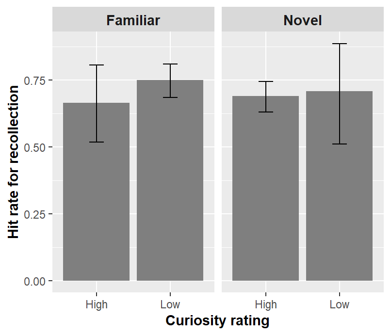

#### 5.3.0.1 Stats on it

```
## Linear mixed-effects model fit by maximum likelihood
##  Data: Encoding.Recall.Old.Collapsed.Interaction[!SubjectNo %in% bad.ps.less.strict]
##         AIC      BIC   logLik
##   -60.86366 -40.5173 38.43183
##
## Random effects:
##  Formula: ~1 | SubjectNo
##         (Intercept)
## StdDev:   0.1620216
##
##  Formula: ~1 | CuriosityRatingType %in% SubjectNo
##          (Intercept)
## StdDev: 0.0005058425
##
##  Formula: ~1 | Group %in% CuriosityRatingType %in% SubjectNo
##         (Intercept)    Residual
## StdDev:   0.1095472 0.008081899
##
## Fixed effects: SeenHit ~ CuriosityRatingType * Group
##                                        Value  Std.Error DF   t-value
## (Intercept)                        0.6894719 0.05048869 39 13.655966
## CuriosityRatingTypeLow             0.0619170 0.04762867 37  1.299995
## GroupNovel                         0.0052898 0.04705737 14  0.112412
## CuriosityRatingTypeLow:GroupNovel -0.0220557 0.07104043 14 -0.310466
##                                   p-value
## (Intercept)                        0.0000
## CuriosityRatingTypeLow             0.2016
## GroupNovel                         0.9121
## CuriosityRatingTypeLow:GroupNovel  0.7608
##  Correlation:
##                                   (Intr) CrsRTL GrpNvl
## CuriosityRatingTypeLow            -0.789
## GroupNovel                        -0.790  0.852
## CuriosityRatingTypeLow:GroupNovel  0.581 -0.725 -0.729
##
## Standardized Within-Group Residuals:
##          Min           Q1          Med           Q3          Max
## -0.243241741 -0.025845551  0.009965021  0.032047434  0.132080928
##
## Number of Observations: 94
## Number of Groups:
##                                     SubjectNo
##                                            40
##            CuriosityRatingType %in% SubjectNo
##                                            78
## Group %in% CuriosityRatingType %in% SubjectNo
##                                            94
```

### 5.3.1 Alternative way to collapse data

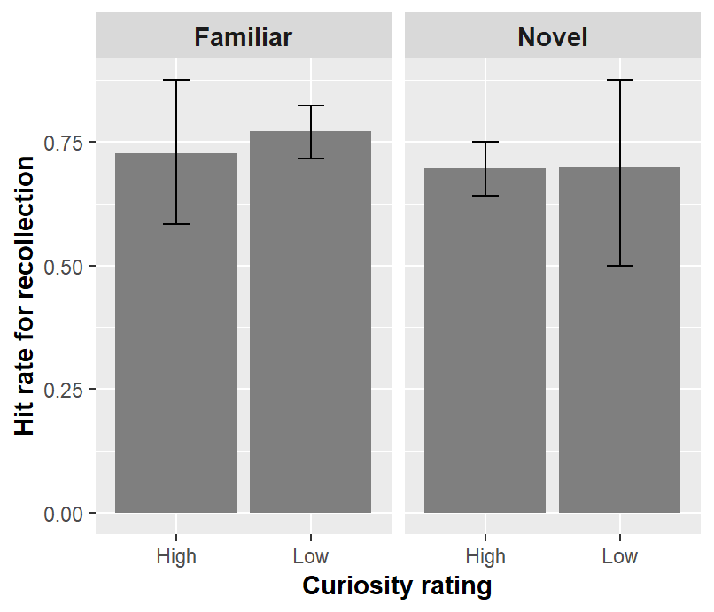

```
## Linear mixed-effects model fit by maximum likelihood
##  Data: Encoding.Recall.Old.Collapsed.Alt.Interaction[!SubjectNo %in%      bad.ps.less.strict]
##         AIC       BIC   logLik
##   -69.22292 -48.70813 42.61146
##
## Random effects:
##  Formula: ~1 | SubjectNo
##         (Intercept)
## StdDev:   0.1454877
##
##  Formula: ~1 | RatingGroup %in% SubjectNo
##         (Intercept)
## StdDev: 0.001331879
##
##  Formula: ~1 | Group %in% RatingGroup %in% SubjectNo
##         (Intercept)   Residual
## StdDev:   0.1105041 0.01094954
##
## Fixed effects: SeenHit ~ RatingGroup * Group
##                                Value  Std.Error DF   t-value p-value
## (Intercept)                0.7637263 0.05124651 39 14.902991  0.0000
## RatingGroupLow             0.0072459 0.04894647 39  0.148038  0.8831
## GroupNovel                -0.0676152 0.04894552 14 -1.381437  0.1888
## RatingGroupLow:GroupNovel  0.0610687 0.07403273 14  0.824888  0.4233
##  Correlation:
##                           (Intr) RtngGL GrpNvl
## RatingGroupLow            -0.827
## GroupNovel                -0.827  0.866
## RatingGroupLow:GroupNovel  0.638 -0.756 -0.756
##
## Standardized Within-Group Residuals:
##         Min          Q1         Med          Q3         Max
## -0.34257847 -0.04236216  0.01169918  0.04209266  0.21192195
##
## Number of Observations: 96
## Number of Groups:
##                             SubjectNo
##                                    40
##            RatingGroup %in% SubjectNo
##                                    80
## Group %in% RatingGroup %in% SubjectNo
##                                    96
```

# 6 Curiosity effects in the *Novel* group

## 6.1 Mean accuracy of item memory as a function of curiosity rating

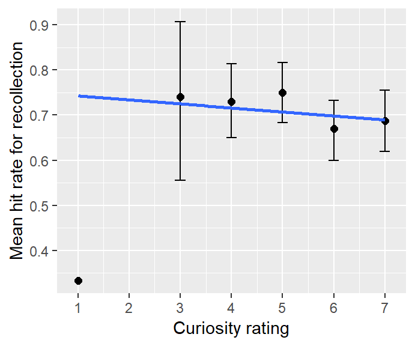